# Pressure's off the Menu! Enjoyable Plating for Healthy Living

[figure not shown]

## Code Display

```python
from IPython.display import HTML
HTML('''
<script src="https://cdnjs.cloudflare.com/ajax/libs/jquery/2.0.3/jquery.min.js
"></script>
<script>
code_show=true;
function code_toggle() {
 if (code_show){
 $('div.jp-CodeCell > div.jp-Cell-inputWrapper').hide();
 } else {
$('div.jp-CodeCell > div.jp-Cell-inputWrapper').show();
 }
 code_show = !code_show
}
$( document ).ready(code_toggle);
</script>
<form action="javascript:code_toggle()"><input type="submit"
value="Click here to toggle on/off the raw code."></form>
''')
```

## Import Libraries and Global Variables & Settings

```python
import dmw2_final
```

```python
import pandas as pd
import numpy as np
import matplotlib.pyplot as plt
import seaborn as sns
import warnings
import re

from scipy.sparse import csr_matrix
from sklearn.decomposition import TruncatedSVD
from sklearn.feature_extraction.text import TfidfVectorizer
from sklearn.exceptions import ConvergenceWarning
from sklearn.neighbors import NearestNeighbors
from sklearn.cluster import (KMeans, AgglomerativeClustering, DBSCAN, OPTICS,
                             cluster_optics_dbscan)
from sklearn.metrics import (silhouette_score, calinski_harabasz_score,
                             davies_bouldin_score)

from nltk.corpus import stopwords
from nltk.stem.snowball import SnowballStemmer
from nltk.stem import PorterStemmer, WordNetLemmatizer

from tqdm.notebook import tqdm, trange
from wordcloud import WordCloud, STOPWORDS, ImageColorGenerator
from PIL import Image as WordImage
from IPython.display import Image
from IPython.display import display, display_html

from plotnine import ggplot, aes, geom_bar
from plotnine.scales import scale_fill_manual
from plotnine import *
import re
from nltk.corpus import stopwords
from nltk.stem import WordNetLemmatizer

# Global settings
%matplotlib inline

# Pandas settings
pd.options.display.float_format = '{:,.2f}'.format
pd.set_option('display.max_colwidth', 20)
pd.set_option('display.max_columns', None)
pd.set_option('mode.chained_assignment', None)

# Error Filters
warnings.filterwarnings("ignore", category=RuntimeWarning)
warnings.filterwarnings("ignore", category=ConvergenceWarning)
warnings.filterwarnings("ignore", category=FutureWarning)
warnings.filterwarnings("ignore")
```

# EXECUTIVE SUMMARY

**High blood pressure, also known as hypertension, is a common chronic condition affecting millions of people worldwide.** It is a major risk factor for cardiovascular disease, stroke, and kidney disease, among other health problems. Diet plays a crucial role in managing hypertension, and people with high blood pressure often struggle to find healthy and tasty recipes that meet their nutritional needs. [1] While there are many recipe websites and software applications available, they do not always provide tailored recommendations for people with specific health conditions such as hypertension. Moreover, **some recipes labeled as healthy may not be appropriate for people with high blood pressure due to their sodium content or other ingredients that can exacerbate the condition.**

This project focused on helping hypertensive consumers overcome the challenge of adhering to dietary recommendations. As the prevalence of this chronic disease continues to rise globally, proper diet management is crucial. However, patients often struggle to cook healthy and tasty meals that fit their nutritional limitations. To address this problem, our team developed a personalized meal recommender system that takes into account consumers' nutritional requirements, taste preferences, cooking skills, and other relevant factors. The goal is to enhance the user experience of hypertensive consumers and empower them to make informed and enjoyable food choices.

The team is confident in the potential of this recommendation system, and we have identified several key areas for improvement and expansion such as, but not limited to the following: (1) enhance the customization capturing consumer specific dietary requirements (2) extend the explainability of the recommended recipes to eaters, (3) expand the recommendation system to include other health conditions such as diabetes, cancer, gout, and others, and (4) maximize the impact and reach of our recommendation system through partnerships with food delivery services.

Overall, this project highlighted the potential of data-driven approaches to promote healthier eating habits, especially for those with specific health concerns such as hypertension. **By leveraging machine learning techniques and nutritional expertise, we can create personalized recommendations that are both enjoyable and beneficial for individuals' health.**

Back to Table of Contents

# TABLE OF CONTENTS

- Executive Summary
- Problem Statement
- Motivation
- List of Tables and Figures
- Methodology
- Data Source and Description
- Data Exploration
- Dimensionality Reduction
- Results
- Conclusion
- Recommendations
- References

# PROBLEM STATEMENT

How the world eats is shifting dramatically. The proliferation of different food options alongside technological advancements increased convenience but at the same time lessened consumers’ nutritional awareness. Given this objective in mind, we explored information from `allrecipes` focusing on this key question that our team seeks to address:

**How can we recommend delicious and healthy recipes to promote the well-being of hypertensive eaters?**

The team's primary focus is on developing a recommendation system that can effectively suggest tasty and nutritious recipes to individuals with hypertension. This question addresses the main challenge of balancing the dietary restrictions required to manage hypertension while still promoting enjoyable and satisfying meals.

Several key considerations such as identifying and incorporating relevant nutritional guidelines, capturing user preferences and dietary restrictions, and developing a robust and accurate recommendation algorithm were taken into consideration. *However, for the time being, the team will only incorporate the World Health Organization's 2,000mg daily sodium restriction as the nutritional guideline.* By addressing these challenges, the team aims to provide an effective solution to promote the well-being of hypertensive individuals while enjoying their meals.

Back to Table of Contents

# MOTIVATION

**Hypertension, or high blood pressure, is a common medical condition that affects millions of people worldwide, including many of our loved ones.** It is a major risk factor for cardiovascular disease, stroke, and other serious health problems, and is a leading cause of premature death globally.

One of the main ways to manage hypertension is through lifestyle modifications, including changes to diet and exercise habits. **For many hypertensive individuals, this means adhering to specific dietary restrictions, such as reducing salt intake and increasing consumption of nutrient-rich foods like fruits, vegetables, and whole grains.**

However, following these dietary restrictions can be challenging for many patients, especially if they feel that they have to sacrifice flavor or enjoyment in their meals. This is where the team aims to help hypertensive patients come in. **By developing a recommendation system that suggests delicious and healthy recipes tailored to their dietary requirements, our team hopes to make it easier for hypertensive individuals to adhere to their restrictions while still enjoying their meals.**

This can have significant health benefits for hypertensive patients, as it can help them to maintain a healthy weight, manage their blood pressure, and reduce their risk of developing other health problems associated with hypertension. **Overall, the team aims to improve the quality of life and health outcomes for hypertensive individuals by helping them to make tasty and nutritious food choices.**

Back to Table of Contents

# LIST OF TABLES AND FIGURES

**Table 1.** Description of the Data per DataFrame

**Table 2.** Features of the Recipes Dataset

**Table 3.** Features of the Ratings Dataset

**Figure 1.** Project Methodology

**Figure 2.** Distribution of Ratings per Rating Value

**Figure 3.** Top 10 Foods with the Most Number of Reviews

**Figure 4.** Top 10 Foods with the Most Number of Sodium content (in mg)

**Figure 5:** Top 10 Foods with the Most Number of Sodium content (in mg) per Serving

**Figure 6:** Top 10 Foods with the Least Number of Sodium content (in mg) per Serving

**Figure 7:** Cumulative Variance Explained

**Figure 8:** Results of k-Means Clustering

**Figure 9:** Results of k-Means Clustering Metrics

**Figure 10:** Final k-Means Clustering

**Figure 11:** Hierarchical Clustering Methods

**Figure 12:** Extracted Cluster Themes

**Figure 13:** FlavorFit Recommender System

**Figure 14:** FlavorFit Recommender System for Sweet Treats

**Figure 15:** FlavorFit Recommender System for Savory Eats

Back to Table of Contents

# METHODOLOGY

[figure not shown]

**Figure 1:** Project Methodology

To develop the proposed recipe recommendation system for hypertensive eaters, the following methodology was employed:

**1. Data Extraction, Cleaning and Processing:**

*Data Extraction*

The recipes, ratings, and nutrients for this study were extracted from allrecipes.com, a popular recipe website that provides nutritional values for each recipe.

*Data Cleaning & Pre-processing*

The following cleaning and preprocessing steps were performed to clean the datasets:

1. Combined the food and nutrients dataframes.
2. Retained only the calories, carbohydrates_g, sugars_g, fat_g, saturated_fat_g, cholesterol_mg, protein_g, dietary_fiber_g, sodium_mg, and calories_from_fat nutrients. Dropped the rest of the nutrients as they either contain null information or will not impact consumers diagnosed with hypertension.
3. Retained only the ratings where the food_id is also in the food datarame.
4. Cleaned the recipe text by employing lemmatization and removing stopwords unique to the dataset (e.g., chef, easy, make, etc).

**2. Text Vectorization and Clustering**

The resulting recipes after the data cleaning and pre-procesing stage are then vectorized for Term Frequency-Inverse Document Frequency (TF-IDF). This is to identify the most important or relevant words in a recipe (e.g., key ingredients and/or preparation methods). Afterwhich, Singular Value Decomposition (SVD), a dimensionality reduction technique most often used in recommender systems, was employed to help identify latent features that are relevant for recipe recommendations.

Finally, using K-means clustering method, the recipes are grouped based on their features like ingredients, preparation, and nutritional values.

Back to Table of Contents

# DATA SOURCE AND DESCRIPTION

For this project, the team focused on exploring the Recipes and Ratings datasets with detailed features as follows:

| DataFrame | Feature | Data Type | Description |
| --- | --- | --- | --- |
| `food` | `itemid` | int64 | ItemID of the recipe |
| `food` | `title` | object | Title of the recipe |
| `food` | `prep_time` | int64 | Preperation time for the recipe |
| `food` | `cook_time` | int64 | Cooking time for the recipe |
| `food` | `ready_time` | int64 | Readying time for the recipe |
| `food` | `ingredients` | object | Ingredients of the recipe |
| `food` | `directions` | object | Directions of the recipe |
| `food` | `url` | object | URL of the recipe |
| `food` | `photo_url` | object | Photo URL of the recipe |
| `nutrients` | `name` | object | Name of the recipe |
| `nutrients` | `url` | object | URL of the recipe |
| `nutrients` | `category` | object | Category of the recipe |
| `nutrients` | `author` | object | Author of the recipe |
| `nutrients` | `summary` | object | Summary of the recipe |
| `nutrients` | `rating` | float64 | Rating per recipe |
| `nutrients` | `rating_count` | int64 | Rating Count per recipe |
| `nutrients` | `review_count` | int64 | Review Count per recipe |
| `nutrients` | `ingredients` | object | Ingredients of the recipe |
| `nutrients` | `directions` | object | Directions of the recipe |
| `nutrients` | `prep` | object | Preparation of the recipe |
| `nutrients` | `cook` | object | Cooking time of each step of the recipe |
| `nutrients` | `total` | object | Total Cooking Time of the recipe |
| `nutrients` | `servings` | int64 | Serving size of the recipe |
| `nutrients` | `yield` | object | Yield of the recipe |
| `nutrients` | `calories` | float64 | Total Calories of the recipe |
| `nutrients` | `carbohydrates_g` | float64 | Total Carbohydrates in grams of the recipe |
| `nutrients` | `sugars_g` | float64 | Total Sugar in grams of the recipe |
| `nutrients` | `fat_g` | float64 | Total Fat in grams of the recipe |
| `nutrients` | `saturated_fat_g` | float64 | Total Saturated Fat in grams of the recipe |
| `nutrients` | `cholesterol_mg` | float64 | Total Cholesterol in milligrams of the recipe |
| `nutrients` | `dietary_fiber_g` | float64 | Total Dietary fiber in grams of the recipe |
| `nutrients` | `sodium_mg` | float64 | Total Sodium in milligrams of the recipe |
| `nutrients` | `calories_from_fat` | float64 | Total Calories from fat of the recipe |
| `nutrients` | `calcium_mg` | float64 | Total Calcium in milligrams of the recipe |
| `nutrients` | `iron_mg` | float64 | Total Iron in milligrams of the recipe |
| `nutrients` | `magnesium_mg` | float64 | Total Magnesium in milligrams of the recipe |
| `nutrients` | `potassium_mg` | float64 | Total Potassium in milligrams of the recipe |
| `nutrients` | `zinc_mg` | float64 | Total Zinc in milligrams of the recipe |
| `nutrients` | `phosphorus_mg` | float64 | Total Vitamin A of the recipe |
| `nutrients` | `vitamin_a_iu_IU` | float64 | Total Phosphorous in milligrams of the recipe |
| `nutrients` | `niacin_equivalents_mg` | float64 | Total Niacin Equivalents in milligrams of the recipe |
| `nutrients` | `vitamin_b6_mg` | float64 | Total Vitamin B6 in milligrams of the recipe |
| `nutrients` | `vitamin_c_mg` | float64 | Total Vitamin C in milligrams of the recipee |
| `nutrients` | `folate_mcg` | float64 | Total Folate in microgram of the recipe |
| `nutrients` | `thiamin_mg` | float64 | Total Thiamin in milligrams of the recipe |
| `nutrients` | `riboflavin_mg` | float64 | Total Riboflavin in milligrams of the recipe |
| `nutrients` | `vitamin_e_iu_IU` | float64 | Total Vitamin E of the recipe |
| `nutrients` | `vitamin_k_mcg` | float64 | Total Vitamin K in micrograms of the recipe |
| `nutrients` | `biotin_mcg` | float64 | Total Biotin in micrograms of the recipe |
| `nutrients` | `vitamin_b12_mcg` | float64 | Total Vitamin B12 in micrograms of the recipe |
| `nutrients` | `mono_fat_g` | float64 | Total Mono Fat in grams of the recipe |
| `nutrients` | `poly_fat_g` | float64 | Total Poly Fat in grams of the recipe |
| `nutrients` | `trans_fatty_acid_g` | float64 | Total Trans Fatty Acid in grams of the recipe |
| `nutrients` | `omega_3_fatty_acid_g` | float64 | Total Omega 3 Fatty Acid in grams of the recipe |
| `nutrients` | `omega_6_fatty_acid_g` | float64 | Total Omega 3 Fatty Acid in grams of the recipe |
| `ratings` | `User_ID` | int64 | User ID of the rater |
| `ratings` | `Food_ID` | int64 | Food ID of the recipe |
| `ratings` | `Rating` | int64 | Rating of the rater per recipe |

Table 1. Description of the Data per DataFrame

From the above table and as discussed in the methodology that the recipes and nutrients were combined, this project focused on exploring the `Recipes` and `Ratings` datasets with detailed features as follows.

  For this project, we used the following nutritional values per recipe: **calories, carbohydrates_g, sugars_g, fat_g, saturated_fat_g, cholesterol_mg, protein_g, dietary_fiber_g, and sodium_mg**. These values were documented based on the ingredients used in each recipe, which were sourced from a reliable nutritional database. By incorporating these nutritional values, eaters with specific dietary needs, or even those simply interested in tracking their nutritional intake, will greatly benefit from this. More specifically, by including the sodium content, eaters with hypertension can manage their condition better.

  Further, adding nutritional values, including sodium content, can help consumers with hypertension manage their condition better. This information can lead to better health choices and outcomes, improved quality of life, and reduced risk of complications such as heart disease and stroke. Overall, including nutritional values in food recipes is a small but significant step towards a healthier lifestyle for everyone.
- The `Ratings` dataset contains 1,555,581 rows and 3 columns, including User_id and Rating information on each recipe given by users.

  In order to increase the reliability of the reviews and ensure that they were written by knowledgeable users, we filtered the dataset to only include reviews written by users who had provided feedback more than 100 times. By doing so, we were able to reduce the influence of potentially biased or unreliable reviews, and focus on the feedback provided by experienced reviewers. This filtering process helped us to ensure the overall quality and accuracy of the reviews used in this analysis.

By analyzing these datasets, we aim to gain insights into the nutritional value of popular recipes, identify trends in the types of ingredients and preparation methods used by allrecipes.com users, as well as understand the ratings and user behavior. In the following sections, we will describe the data analysis process and present our findings.

| Features | Data Type | Description |
| --- | --- | --- |
| Food_ID | int | unique identifier of the food item |
| name | string | name of the food item |
| ingredients | string | list of ingredients |
| photo_url | string | URL to a photo of the food item |
| calories | float | total number of calories |
| carbohydrates_g | float | total number of carbohydrates in grams |
| sugars_g | float | total number of sugars in grams |
| fat_g | float | total number of fat in grams |
| saturated_fat_g | float | total number of saturated fat in grams |
| cholesterol_mg | float | total amount of cholesterol in milligrams |
| protein_g | float | total number of protein in grams |
| dietary_fiber_g | float | total number of dietary fiber in grams |
| sodium_mg | float | total amount of sodium in milligrams |
| calories_from_fat | float | total number of calories from fat |

| Features | Data Type | Description |
| --- | --- | --- |
| Food_ID | int | unique identifier for the food item |
| User_id | int | unique identifier for the user who rated the food item |
| Rating | float | rating given by the user for the food item |

Back to Table of Contents

# DATA EXPLORATION

## Data Collection

`Allrecipes.com` is a popular recipe-sharing website that has been providing home cooks with a vast collection of recipes for over two decades. One of the unique features of `allrecipes.com` is that it includes nutritional information for many of its recipes. This feature has made it a go-to source for individuals who are looking for healthier meal options or who have specific dietary needs.

In this study, the team scraped selected data from `allrecipes.com` due to its diverse food options and the availability of nutritional information for majority of its recipes. By leveraging this information, the team could provide more accurate and comprehensive information about the recipes, including nutritional values such as _calories, carbohydrates_g, sugars_g, fat_g, saturated_fat_g, cholesterol_mg, protein_g, dietary_fiber_g, and sodium*mg*. This information can benefit a wide range of users, from consumers with specific dietary needs to consumers simply interested in tracking their nutritional intake.

```python
food_raw, nutrients, ratings_raw = dmw2_final.read_data()
```

```python
food_raw.shape, nutrients.shape, ratings_raw.shape
```

```
((12351, 9), (35516, 47), (1555581, 3))
```

Back to Table of Contents

## Data Preparation

The team performed **data preparation, cleaning, and preprocessing** procedures to ensure the datasets' quality and appropriateness for subsequent analysis addressing any notable concerns such as missing data or irregular formatting, if any.

### Recipe Dataset

#### Data Preview

```python
dmw2_final.df_exploration(food_raw)
```

**Number of Data Points:** 12351

**Number of Features:** 9

**Number of Nulls:** 6

|  | itemid | title | prep_time | cook_time | ready_time | ingredients | directions | url | photo_url |
| --- | --- | --- | --- | --- | --- | --- | --- | --- | --- |
| 0 | 7000 | Golden Crescent ... | 25 | 15 | 190 | yeast,water,whit... | Dissolve yeast i... | https://www.allr... | https://images.m... |
| 1 | 7001 | Poppy Seed Bread... | 15 | 60 | 80 | flour,salt,bakin... | 'Preheat oven to... | https://www.allr... | https://images.m... |
| 2 | 7003 | Applesauce Bread... | 10 | 80 | 90 | flour,egg,white ... | Preheat oven to ... | https://www.allr... | https://images.m... |

#### Impute missing values

```python
food_raw = food_raw.bfill(axis=1)
food_raw = food_raw.ffill(axis=1)
dmw2_final.df_exploration(food_raw, display_df=False)
```

**Number of Data Points:** 12351

**Number of Features:** 9

**Number of Nulls:** 0

*Note: Missing values were filled-out using both the backfill and forward fill.*

#### Add Nutritional Values

Nutritional values in food recipes are important for consumers with specific dietary restrictions or personal preferences as this allow consumers to make informed decisions about what to eat based on their varying nutritional needs.

```python
food_nutrients = dmw2_final.add_nutrients(food_raw, nutrients)
dmw2_final.df_exploration(food_nutrients)
```

**Number of Data Points:** 5238

**Number of Features:** 55

**Number of Nulls:** 75476

|  | name | url | category | author | summary | rating | rating_count | review_count | ingredients_x | directions_x | prep | cook | total | servings | yield | calories | carbohydrates_g | sugars_g | fat_g | saturated_fat_g | cholesterol_mg | protein_g | dietary_fiber_g | sodium_mg | calories_from_fat | calcium_mg | iron_mg | magnesium_mg | potassium_mg | … |
| --- | --- | --- | --- | --- | --- | --- | --- | --- | --- | --- | --- | --- | --- | --- | --- | --- | --- | --- | --- | --- | --- | --- | --- | --- | --- | --- | --- | --- | --- | --- |
| 0 | Dessert Crepes | 19037 | breakfast-and-br... | ANN57 | Essential crepe ... | 4.80 | 1156 | 794 | 4 eggs, lightly... | In large bowl, w... | 10 mins | 10 mins | 20 mins | 8 | 8 crepes | 163.80 | 17.20 | 5.30 | 7.70 | 3.40 | 111.10 | 6.40 | 0.40 | 234.50 | 69.00 | 65.60 | 1.20 | 11.20 | 115.40 | … |
| 1 | Quick and Easy P... | 20171 | bread | CHEF RIDER | This is a great ... | 4.70 | 3741 | 2794 | 1 (.25 ounce) pa... | Preheat oven to ... | NaN | NaN | NaN | 8 | 1 12-inch pizza ... | 169.80 | 28.10 | 0.60 | 4.00 | 0.60 | NaN | 4.80 | 1.10 | 292.80 | 36.30 | 7.30 | 1.80 | 10.50 | 55.40 | … |
| 2 | Homemade Mac and... | 11679 | main-dish | Judy | This is a nice r... | 4.16 | 2550 | 1863 | 8 ounces uncooke... | Cook macaroni ac... | 20 mins | 30 mins | 50 mins | 4 | 4 servings | 858.20 | 66.70 | 10.70 | 48.70 | 29.90 | 141.60 | 37.70 | 3.40 | 879.30 | 438.20 | 863.10 | 3.30 | 76.20 | 458.80 | … |

#### Preview Data with Nutritional Values

```python
df_food = dmw2_final.get_food(food_nutrients)
dmw2_final.df_exploration(df_food)
```

**Number of Data Points:** 5238

**Number of Features:** 20

**Number of Nulls:** 1437

|  | Food_ID | Name | prep_time | cook_time | ready_time | ingredients | directions_y | photo_url | servings | yield | calories | carbohydrates_g | sugars_g | fat_g | saturated_fat_g | cholesterol_mg | protein_g | dietary_fiber_g | sodium_mg | calories_from_fat |
| --- | --- | --- | --- | --- | --- | --- | --- | --- | --- | --- | --- | --- | --- | --- | --- | --- | --- | --- | --- | --- |
| 0 | 19037 | Dessert Crepes R... | 0 | 10 | 20 | egg,milk,butter,... | In large bowl, w... | https://images.m... | 8 | 8 crepes | 163.80 | 17.20 | 5.30 | 7.70 | 3.40 | 111.10 | 6.40 | 0.40 | 234.50 | 69.00 |
| 1 | 20171 | Quick and Easy P... | 10 | 20 | 30 | yeast,white suga... | 'Preheat oven to... | https://images.m... | 8 | 1 12-inch pizza ... | 169.80 | 28.10 | 0.60 | 4.00 | 0.60 | NaN | 4.80 | 1.10 | 292.80 | 36.30 |
| 2 | 11679 | Homemade Mac and... | 0 | 30 | 50 | macaroni,cheddar... | Cook macaroni ac... | https://images.m... | 4 | 4 servings | 858.20 | 66.70 | 10.70 | 48.70 | 29.90 | 141.60 | 37.70 | 3.40 | 879.30 | 438.20 |

#### Impute missing values

```python
df_food = df_food.bfill(axis=1)
df_food = df_food.ffill(axis=1)
dmw2_final.df_exploration(df_food, display_df=False)
```

**Number of Data Points:** 5238

**Number of Features:** 20

**Number of Nulls:** 0

*Note: Missing values were filled-out using both the backfill and forward fill.*

### Ratings Dataset

#### Data Preview

```python
dmw2_final.df_exploration(ratings_raw)
```

**Number of Data Points:** 1555581

**Number of Features:** 3

**Number of Nulls:** 0

|  | User_ID | Food_ID | Rating |
| --- | --- | --- | --- |
| 0 | 675719 | 7000 | 5 |
| 1 | 1478626 | 7000 | 5 |
| 2 | 608663 | 7000 | 5 |

As discussed above, in order to increase the reliability of the reviews and ensure that they were written by knowledgeable users, we filtered the dataset to only include reviews written by users who had provided feedback more than 100 times. By doing so, we were able to reduce the influence of potentially biased or unreliable reviews, and focus on the feedback provided by experienced reviewers.

```python
df_ratings = dmw2_final.get_ratings(ratings_raw, df_food)
dmw2_final.df_exploration(df_ratings)
```

**Number of Data Points:** 21902

**Number of Features:** 3

**Number of Nulls:** 0

|  | Food_ID | User_ID | Rating |
| --- | --- | --- | --- |
| 2 | 19037 | 15350275 | 5 |
| 9 | 19037 | 821228 | 5 |
| 19 | 19037 | 741727 | 5 |

Back to Table of Contents

## Exploratory Data Analysis

The team performed in-depth exploration on the datasets discussed above to better comprehend its contents and structures. This critical process ensured that the subsequent analysis will be based on accurate and dependable data.

We took a closer look at the distribution of **ratings** by plotting the **total number of ratings per rating value** alongside the **percentage of ratings per rating value**. By presenting these two metrics side by side, we were able to identify any potential patterns or trends in the data and gain valuable insights into the overall distribution of ratings. This process helped us to identify the most common rating values and determine the most effective way to analyze and interpret the data.

```python
# Calculate the percentage of each rating value
total = df_ratings.Rating.count()
percent_plot = pd.DataFrame({"Total": df_ratings.Rating.value_counts()})
percent_plot.reset_index(inplace=True)
percent_plot.rename(columns={"index": "Rating"}, inplace=True)
percent_plot["Percent"] = percent_plot["Total"].apply(lambda x: (x/total)*100)

# Plot the first bar chart
plt.figure(figsize=(10, 5))
ax1 = plt.subplot(1, 2, 1)
sns.barplot(x="Rating", y="Total", data=percent_plot, color="#808080")
plt.xlabel("Rating")
plt.ylabel("Total")
plt.title("Total Ratings per Rating Value")

# Plot the second bar chart
ax2 = plt.subplot(1, 2, 2)
sns.barplot(x="Rating", y="Percent", data=percent_plot, color="#ff7f0e")
plt.xlabel("Rating")
plt.ylabel("Percent")
plt.title("Percentage of Ratings per Rating Value")

# Save the plot as a PNG file
plt.savefig("plots.png")

# Create an HTML img tag to display the image
img_tag = f'<img src="plots.png" alt="plots" style="display:block;margin-left:auto;margin-right:auto;width:80%;">'

# Display the img tag in the Jupyter Notebook
display(HTML(img_tag))
plt.close()
```

[figure not shown]

**Figure 2:** Distribution of Ratings per Rating Value

From both the total ratings and percentage of ratings per rating value, we can infer that majority of the dishes in the Recipes datasets have a rating of 5.0. Despite the fact that ratings are subjective, we can deduce that majority of the dishes in our dataset are delicious and approved by the foodies out there.

```python
dmw2_final.display_top_foods(df_ratings, df_food)
```

Top 10 Foods with the Most Number of Reviews

| Key West Chicken Recipe Sodium(mg): 735.3 Total Rating: 182 Number of Reviews: 42 | Orzo with Parmesan and Basil Recipe Sodium(mg): 196.7 Total Rating: 184 Number of Reviews: 41 |
| --- | --- |
| Oven Roasted Potatoes Recipe Sodium(mg): 304.0 Total Rating: 184 Number of Reviews: 41 | Toasted Garlic Bread Recipe Sodium(mg): 376.2 Total Rating: 181 Number of Reviews: 40 |
| Pan Sodium(mg): 524.6 Total Rating: 166 Number of Reviews: 37 | 'Todd''s Famous Blueberry Pancakes Recipe ' Sodium(mg): 397.4 Total Rating: 154 Number of Reviews: 36 |
| Savory Garlic Marinated Steaks Recipe Sodium(mg): 2496.5 Total Rating: 152 Number of Reviews: 35 | Slow Cooker Italian Beef for Sandwiches Recipe Sodium(mg): 819.1 Total Rating: 154 Number of Reviews: 33 |
| Shrimp Scampi Bake Recipe Sodium(mg): 681.2 Total Rating: 154 Number of Reviews: 33 | Salsa Chicken Recipe Sodium(mg): 863.1 Total Rating: 152 Number of Reviews: 33 |

**Figure 3:** Top 10 Foods with the Most Number of Reviews

```python
dmw2_final.display_top_10_sodium(df_food)
```

Top 10 Foods with theMost Number of Sodium Content (in mg)

| 'Baker''s Clay Recipe ' Sodium(mg): 93427.4 Servings: 1 Sodium Content Per Serving:93427.4 | The Best Marinade Around Recipe Sodium(mg): 7220.2 Servings: 1 Sodium Content Per Serving:7220.2 |
| --- | --- |
| Cornucopia Recipe Sodium(mg): 6957.1 Servings: 1 Sodium Content Per Serving:6957.1 | Tasso Ham Recipe Sodium(mg): 6665.2 Servings: 30 Sodium Content Per Serving:222.17 |
| Hawaiian Chicken I Recipe Sodium(mg): 5830.9 Servings: 6 Sodium Content Per Serving:971.82 | 'Irene''s Christmas Cheese Dip Recipe ' Sodium(mg): 4813.1 Servings: 3 Sodium Content Per Serving:1604.37 |
| Stuffed Acorn Squash Recipe Sodium(mg): 4671.2 Servings: 2 Sodium Content Per Serving:2335.6 | Steak Marinade Recipe Sodium(mg): 4601.2 Servings: 2 Sodium Content Per Serving:2300.6 |
| Scotch Eggs Recipe Sodium(mg): 4278.2 Servings: 4 Sodium Content Per Serving:1069.55 | Simple BBQ Ribs Recipe Sodium(mg): 4260.3 Servings: 4 Sodium Content Per Serving:1065.08 |

**Figure 4:** Top 10 Foods with the Most Number of Sodium content (in mg)

Above list of recipes were the top 10 foods based on their sodium content (in mg). The highest on the list is Baker's clay, which is from the `allrecipes.com` website, is used to make non-edible cookies that make lovely ornaments to hang on your Christmas Tree [4]. Its main ingredients are 4 cups of all-purpose flour, 1 1/2 cups water, and 1 cup salt. Given that the sodium content is beyond the 2,000mg threshold, no need to remove this outlier as this will be automatically be removed when recommending recipes to hypertensive eaters.

Other dishes in the list are mostly main dishes with meat as its main ingredient - ribs, steak, ham, others.

```python
dmw2_final.display_top_10_sodium_serving(df_food)
```

Top 10 Foods with the Most Number ofSodium content (in mg) per Serving

| 'Baker''s Clay Recipe ' Sodium(mg): 93427.4 Servings: 1 Sodium Content Per Servings:93427.4 | The Best Marinade Around Recipe Sodium(mg): 7220.2 Servings: 1 Sodium Content Per Servings:7220.2 |
| --- | --- |
| Cornucopia Recipe Sodium(mg): 6957.1 Servings: 1 Sodium Content Per Servings:6957.1 | The Real Reuben Recipe Sodium(mg): 2716.2 Servings: 1 Sodium Content Per Servings:2716.2 |
| Stuffed Acorn Squash Recipe Sodium(mg): 4671.2 Servings: 2 Sodium Content Per Servings:2335.6 | Steak Marinade Recipe Sodium(mg): 4601.2 Servings: 2 Sodium Content Per Servings:2300.6 |
| Reuben Sandwich I Recipe Sodium(mg): 1682.7 Servings: 1 Sodium Content Per Servings:1682.7 | 'Irene''s Christmas Cheese Dip Recipe ' Sodium(mg): 4813.1 Servings: 3 Sodium Content Per Servings:1604.37 |
| Creole Shrimp Recipe Sodium(mg): 3144.9 Servings: 2 Sodium Content Per Servings:1572.45 | Pig Burger Recipe Sodium(mg): 1572.1 Servings: 1 Sodium Content Per Servings:1572.1 |

**Figure 5:** Top 10 Foods with the Most Number of Sodium content (in mg) per Serving

Above list of recipes were the top 10 foods based the sodium content (in mg) per serving. Ignoring Baker's clay which was already discussed in the previous list of top 10 items, the dishes returned this time are those which are stuffed and sandwich (burger).

```python
dmw2_final.display_low_10_sodium_serving(df_food)
```

Top 10 Foods with the Least Number ofSodium content (in mg) per serving

| Homemade Vanilla Recipe Sodium(mg): 0.2 Servings: 150 Sodium Content Per Servings: 0.0 | Submarine Flavors Recipe Sodium(mg): 0.1 Servings: 24 Sodium Content Per Servings: 0.0 |
| --- | --- |
| Italian Herb Infused Olive Oil Recipe Sodium(mg): 0.1 Servings: 12 Sodium Content Per Servings: 0.01 | Essene Bread Recipe Sodium(mg): 0.1 Servings: 12 Sodium Content Per Servings: 0.01 |
| Peach Preserves Recipe Sodium(mg): 0.7 Servings: 64 Sodium Content Per Servings: 0.01 | Chicken Gravy Recipe Sodium(mg): 0.2 Servings: 16 Sodium Content Per Servings: 0.01 |
| Kruschicki Recipe Sodium(mg): 1.5 Servings: 120 Sodium Content Per Servings: 0.01 | Healthy Banana Cookies Recipe Sodium(mg): 0.5 Servings: 36 Sodium Content Per Servings: 0.01 |
| Best White Icing Ever Recipe Sodium(mg): 0.3 Servings: 20 Sodium Content Per Servings: 0.02 | Sugar Cookie Frosting Recipe Sodium(mg): 0.8 Servings: 48 Sodium Content Per Servings: 0.02 |

**Figure 6:** Top 10 Foods with the Least Number of Sodium content (in mg) per Serving

Above list of recipes were the bottom 10 foods based on its sodium content (in mg) per serving. Scanning the returned list of dishes, it does not look appetizing on their own, as it seems that these foods are complementary to other foods or should be eaten together with other dishes.

Back to Table of Contents

# DIMENSIONALITY REDUCTION

Dimensionality reduction refers to the process of reducing the number of features in a dataset while retaining and being able to explain the variation in the original dataset as much as possible.

For the purpose of this study, given the number and nature of features we have, we used Truncated Singular Value Decomposition since it is recommended for densed data and datasets with sparse data, in which many of the row values are zero. [5] Given that we vectorized the ingredients, the returned dataset was highly sparsed, hence the reason for choosing SVD for dimensionality reduction.

```python
df_corpus = dmw2_final.get_ingredient_matrix(df_food)
dmw2_final.df_exploration(df_corpus)
```

**Number of Data Points:** 5230

**Number of Features:** 253

**Number of Nulls:** 0

|  | almond | apple | artichoke | avocado | bacon | bake | baking | baking powder | baking soda | banana | basil | bay | bay leaf | bean | beef | beef onion | bell | bell pepper | black | black pepper | bread | broccoli | broth | brown | brown sugar | butter | butter brown | butter cream | butter egg | … |
| --- | --- | --- | --- | --- | --- | --- | --- | --- | --- | --- | --- | --- | --- | --- | --- | --- | --- | --- | --- | --- | --- | --- | --- | --- | --- | --- | --- | --- | --- | --- |
| 0 | 0.00 | 0.00 | 0.00 | 0.00 | 0.00 | 0.00 | 0.00 | 0.00 | 0.00 | 0.00 | 0.00 | 0.00 | 0.00 | 0.00 | 0.00 | 0.00 | 0.00 | 0.00 | 0.00 | 0.00 | 0.00 | 0.00 | 0.00 | 0.00 | 0.00 | 0.18 | 0.00 | 0.00 | 0.00 | … |
| 1 | 0.00 | 0.00 | 0.00 | 0.00 | 0.00 | 0.00 | 0.00 | 0.00 | 0.00 | 0.00 | 0.00 | 0.00 | 0.00 | 0.00 | 0.00 | 0.00 | 0.00 | 0.00 | 0.00 | 0.00 | 0.37 | 0.00 | 0.00 | 0.00 | 0.00 | 0.00 | 0.00 | 0.00 | 0.00 | … |
| 2 | 0.00 | 0.00 | 0.00 | 0.00 | 0.00 | 0.00 | 0.00 | 0.00 | 0.00 | 0.00 | 0.00 | 0.00 | 0.00 | 0.00 | 0.00 | 0.00 | 0.00 | 0.00 | 0.00 | 0.00 | 0.30 | 0.00 | 0.00 | 0.00 | 0.00 | 0.37 | 0.00 | 0.00 | 0.00 | … |

```python
dmw2_final.plot_variance_explained(df_corpus)
```

[figure not shown]

**Figure 7:** Cumulative variance explained

The SVD analysis of a matrix indicated that to explain at least 80% of the variance, **109** components were required based on the cumulative proportion of variance explained by the singular values

```python
df_svs = dmw2_final.perform_svd(dmw2_final.n_sv, df_corpus)
dmw2_final.df_exploration(df_svs)
```

**Number of Data Points:** 5230

**Number of Features:** 109

**Number of Nulls:** 0

| Name | SV1 | SV2 | SV3 | SV4 | SV5 | SV6 | SV7 | SV8 | SV9 | SV10 | SV11 | SV12 | SV13 | SV14 | SV15 | SV16 | SV17 | SV18 | SV19 | SV20 | SV21 | SV22 | SV23 | SV24 | SV25 | SV26 | SV27 | SV28 | SV29 | … |
| --- | --- | --- | --- | --- | --- | --- | --- | --- | --- | --- | --- | --- | --- | --- | --- | --- | --- | --- | --- | --- | --- | --- | --- | --- | --- | --- | --- | --- | --- | --- |
| Dessert Crepes Recipe | 0.38 | 0.20 | -0.04 | -0.02 | -0.13 | 0.15 | -0.01 | -0.13 | 0.07 | 0.10 | 0.04 | -0.00 | 0.16 | 0.17 | -0.00 | 0.04 | -0.04 | -0.03 | -0.07 | -0.16 | 0.07 | 0.02 | -0.03 | -0.06 | 0.08 | 0.13 | -0.11 | 0.01 | -0.11 | … |
| Quick and Easy Pizza Crust Recipe | 0.33 | 0.06 | -0.09 | 0.07 | -0.03 | 0.13 | 0.11 | -0.26 | 0.24 | 0.18 | 0.17 | -0.16 | -0.23 | 0.08 | 0.15 | -0.03 | -0.15 | 0.14 | 0.18 | -0.05 | -0.16 | 0.01 | 0.06 | 0.04 | -0.00 | 0.02 | 0.09 | -0.15 | 0.01 | … |
| Homemade Mac and Cheese Recipe | 0.23 | 0.00 | 0.03 | -0.08 | -0.23 | 0.16 | -0.07 | 0.00 | -0.11 | 0.05 | 0.17 | 0.20 | 0.04 | 0.35 | 0.08 | 0.11 | -0.11 | -0.01 | -0.07 | -0.06 | 0.05 | 0.09 | 0.04 | -0.09 | 0.06 | 0.00 | -0.00 | -0.00 | -0.10 | … |

Above table provides a detailed breakdown of all 109 singular values retained and its corresponding weights.

Back to Table of Contents

# RESULTS

## CLUSTERING

When selecting the best clustering method for dataset, we took into account below factors:

- results of internal validation metrics such as **Silhouette Score, Davies-Bouldin index, and Calinski-Harabasz index**;
- evaluation through visual inspection the resulting clusters when projected onto the two selected singular value components of the ingredients dataset; and
- the sensibility of the resulting cluster interpretations based on domain expertise.

On the other hand, for the hierarchical methods, we performed sensitivity analyses on the dendrogram cut-off points. Through this thorough evaluation process, we were able to identify the optimal clustering method for the input data and gain valuable insights into its underlying structure.

### K-Means

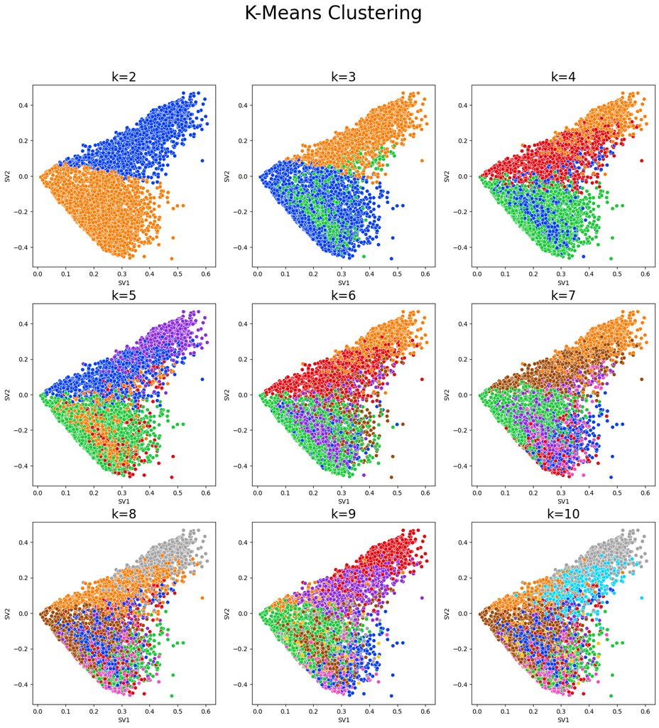

```python
dmw2_final.evaluate_kmeans_clusters(dmw2_final.final_tsvd)
```

**Figure 8:** Results of k-Means Clustering

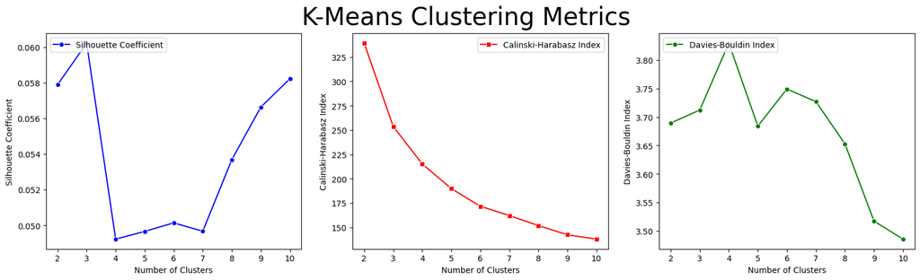

```python
dmw2_final.show_internal_validation(dmw2_final.silhouette_scores,
                                    dmw2_final.ch_scores,
                                    dmw2_final.db_scores)
```

**Figure 9:** Results of k-Means Clustering Metrics

```python
dmw2_final.run_kmeans(dmw2_final.final_tsvd, df_corpus, dmw2_final.feature_names)
```

[figure not shown]

**Figure 10:** Final K-Means Clustering

### Single, Complete, Average, and Ward

```python
dmw2_final.plot_dendrograms(dmw2_final.final_tsvd)
```

[figure not shown]

**Figure 11:** Hierarchal Clustering Methods

This visualization helps us gain a better understanding of the clustering process by displaying the unique outcomes generated by four different linkage methods: single, complete, average, and Ward. Given that Ward linkage may produce similar clustering results as k-Means but can be computationally expensive, it may be more reasonable to choose k-Means clustering.

## WORDCLOUD

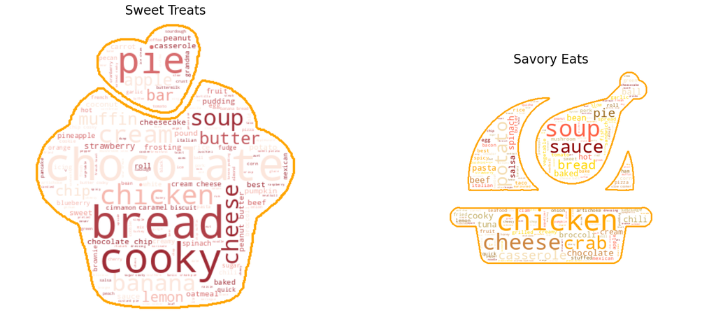

```python
dmw2_final.create_word_clouds(df_food, dmw2_final.cluster_indexes)
```

**Figure 12:** Extracted Cluster Themes

We utilized k-Means clustering with two clusters to generate two word clouds based on the frequency of terms in each cluster, labeling them as **"Sweet Treats"** and **"Savory Eats"**. The resulting word clouds provided a concise visual summary of the main themes and topics associated with each category, enabling us to easily identify the most relevant recipes for each group. By using this approach, we were able to gain valuable insights into the underlying structure of the input data and facilitate more efficient recipe recommendations or menu planning.

## RECOMMENDER SYSTEM

[figure not shown]

**Figure 13:** FlavorFit Recommender System

### Collaborative Filtering

#### Cluster 1: Sweet Treats

```python
dmw2_final.food_recommendation1(df_food, df_ratings, 'Creamy Caramel Flan Recipe')
```

[output not shown]

**Figure 14:** FlavorFit Recommender System for Sweet Treats

#### Cluster 2: Savory Eats

```python
dmw2_final.food_recommendation2(df_food, df_ratings, 'Homemade Mac and Cheese Recipe')
```

[output not shown]

**Figure 15:** FlavorFit Recommender System for Savory Eats

Back to Table of Contents

# CONCLUSION

The team used *k-Means clustering* to explore the structure of the recipe dataset and **discovered two main clusters: Sweet Treats and Savory Eats**. This information can be useful for identifying popular flavor profiles and for tailoring recipe recommendations based on individual preferences. Moreover, by leveraging *Neighborhood-Based Collaborative Filtering* and capturing nutritional thresholds for hypertensive individuals, our recommendation system was able to provide recipe suggestions that are both delicious and healthy. **This has the potential to help hypertensive patients adhere to dietary restrictions and improve their overall health outcomes.**

**Overall, our study highlights the potential of data-driven approaches to promote healthier eating habits, especially for those with specific health concerns such as hypertension.** By leveraging machine learning techniques and nutritional expertise, we can create personalized recommendations that are both enjoyable and beneficial for individuals' health.

Back to Table of Contents

# RECOMMENDATIONS

The team is confident in the potential of our recommendation system, and we have identified several key areas for improvement and expansion. These include:

1. User Value:

- **To enhance the customization of our recommendation system**, we plan to capture more customized nutritional thresholds beyond the current 2,000 mg sodium daily restriction for hypertensive individuals. While this restriction is recommended by the World Health Organization, there may be individuals whose doctors have prescribed different thresholds based on their specific health needs. By capturing more personalized nutritional thresholds, our system can provide more tailored recipe recommendations to meet the diverse dietary needs of individuals with hypertension. Therefore, the team aims to improve the existing system by incorporating additional customized nutritional thresholds to accommodate a wider range of scenarios. *This would further enhance the personalization of our recommendation system and provide more accurate and relevant recipe recommendations to our users.* </br>

[output not shown]

1. Business Value:
   - **To expand our recommendation system to include other health conditions such as cancer, gout, and others so as to significantly improve the health outcomes of individuals with these conditions.** By leveraging the same data extraction, cleaning, processing, text vectorization and clustering, and recommendation system methodologies used for hypertensive patients, we can tailor our system to capture the nutritional thresholds and dietary restrictions specific to these health conditions. This can enable individuals with these conditions to find recipes that fit their dietary requirements and improve their overall health outcomes. Furthermore, *expanding to other health conditions can also potentially increase the user base and reach of our recommendation system, leading to greater impact and success.* </br>
   - **To maximize the impact and reach of our recommendation system, we plan to explore partnerships with food delivery services.** This partnership will allow us to integrate our recommendation system with their platforms, *reaching a wider audience of potential users*. Additionally, partnering with food delivery services could *potentially provide a new revenue stream.* Moreover, by collaborating with these services, we can gain access to vast amounts of consumer purchase behavior data, which can help us *improve the performance of our algorithm*. With this data, we can fine-tune our recommendation system to better align with user preferences and dietary needs, ultimately leading to improved health outcomes for individuals with hypertension and other health conditions.

Back to Table of Contents

# REFERENCES

[1] Hypertension. (2021, August 25). World Health Organization. https://www.who.int/news-room/fact-sheets/detail/hypertension.

[2] `allrecipes.com` website. https://www.allrecipes.com.

[3] World Heart Federation. https://world-heart-federation.org.

[4] Baker's Clay. (2022, July 22). Johanna. https://www.allrecipes.com/recipe/11125/bakers-clay/

[5] 11 Dimensionality reduction techniques you should know in 2021. (2021, Apr 14). Rukshan Pramoditha. https://towardsdatascience.com/11-dimensionality-reduction-techniques-you-should-know-in-2021-dcb9500d388b

Back to Table of Contents